# Tarea 1 Mineria de Datos

David Romero, Luisa De La Horita,David Moreno

2024-02-22

### 0.0.1 Universidad de los Andes Minería de Datos – MIIA 4200

Profesor: Rafael Amaya Gómez

# 1 Punto 1

```r
# Leemos datos meteorológicos (WeatherData_1.xlsx) y almacenarlos en el dataframe 'weather'
weather <- read_excel("WeatherData_1.xlsx", skip = 1, col_names = c("Date", "Rainfall depth (mm)", "Air temperature (°C)", "Air humidity (%)", "Windspeed (km/h)"))

# Leer datos de caudal (InflowData_1.xlsx) y almacenarlos en el dataframe 'inflow'
inflow <- read_excel("InflowData_1.xlsx", skip = 1, col_names = c("Date", "DMA A", "DMA B", "DMA C", "DMA D", "DMA E", "DMA F", "DMA G", "DMA H", "DMA I", "DMA J"))

# Convertir la columna Date al formato POSIXct (fecha y hora) en ambos dataframes
weather$Date <- as.POSIXct(weather$Date, format = "%d/%m/%Y %H:%M")
inflow$Date <- as.POSIXct(inflow$Date, format = "%d/%m/%Y %H:%M")

# Combinar los dataframes de caudal e datos meteorológicos por la columna "Date", conservando todas las filas de caudal
df_data <- merge(inflow, weather, by = "Date", all.x = TRUE)

# Eliminar filas duplicadas basadas en la columna "Date", manteniendo solo la primera ocurrencia
df_data <- df_data[!duplicated(df_data$Date, fromLast = TRUE), ]
```

Primero, procedemos a leer los dos conjuntos de datos y renombrar las columnas con nombres descriptivos. Para facilitar la unión de los conjuntos, utilizaremos “Date” como nombre común para la columna que representa la fecha.

Luego, convertiremos la columna “Date” al formato POSIXct para asegurarnos de que esté en el formato correcto, que es día/mes/año/hora/minuto.

Posteriormente, creamos la variable df_data y unimos las dos bases de datos mediante un left join de la base de datos “Inflow” con la base “weather”.

### 1.0.1 Procesamiento de los datos

```r
str(df_data)
```

```
## 'data.frame':    13678 obs. of  15 variables:
##  $ Date                : POSIXct, format: "2021-01-01 00:00:00" "2021-01-01 01:00:00" ...
##  $ DMA A               : chr  "#N/A" "#N/A" "#N/A" "#N/A" ...
##  $ DMA B               : chr  "#N/A" "#N/A" "#N/A" "#N/A" ...
##  $ DMA C               : chr  "3.7" "3.5625" "3.2725" "2.84" ...
##  $ DMA D               : chr  "#N/A" "#N/A" "#N/A" "#N/A" ...
##  $ DMA E               : chr  "#N/A" "#N/A" "#N/A" "#N/A" ...
##  $ DMA F               : chr  "#N/A" "#N/A" "#N/A" "#N/A" ...
##  $ DMA G               : chr  "#N/A" "#N/A" "#N/A" "#N/A" ...
##  $ DMA H               : chr  "#N/A" "#N/A" "#N/A" "#N/A" ...
##  $ DMA I               : chr  "#N/A" "#N/A" "#N/A" "#N/A" ...
##  $ DMA J               : chr  "#N/A" "#N/A" "#N/A" "#N/A" ...
##  $ Rainfall depth (mm) : num  0 0 0 0 0 0.1 0 0 0.5 0 ...
##  $ Air temperature (°C): num  7.2 7.3 7.6 8.2 7.7 7.5 7.6 7.6 7.2 8 ...
##  $ Air humidity (%)    : num  79 79 78 75 77 81 82 84 91 86 ...
##  $ Windspeed (km/h)    : num  9 6 4 4 7 8 8 9 9 9 ...
```

Aqui vemos que los tipos de datos de las las columnas son númericos y de tipo chr que es string, acá vemos un problema y es que esta tomando el string “#N/A” no como vacio sino como string, las demás variables de DMA deberian ser númericas para esto vamos a hacer una tranformación a los datos

```r
df_data <- df_data %>%
  mutate(
    # Primera operación: Manejar columnas de tipo caracter
    across(where(is.character), ~ {
      # Reemplaza "#N/A" con NA, luego extrae números y convierte a numérico
      as.numeric(gsub("[^0-9.]+", "", ifelse(. == "#N/A", NA, .)))
    }),
    # Segunda operación: Convertir columnas DMA a enteros
    across(c(`DMA A`, `DMA B`, `DMA C`, `DMA D`, `DMA E`, `DMA F`, `DMA G`, `DMA H`, `DMA I`, `DMA J`), as.integer)
  )

str(df_data)
```

```
## 'data.frame':    13678 obs. of  15 variables:
##  $ Date                : POSIXct, format: "2021-01-01 00:00:00" "2021-01-01 01:00:00" ...
##  $ DMA A               : int  NA NA NA NA NA NA NA NA NA NA ...
##  $ DMA B               : int  NA NA NA NA NA NA NA NA NA NA ...
##  $ DMA C               : int  3 3 3 2 2 2 2 3 3 4 ...
##  $ DMA D               : int  NA NA NA NA NA NA NA NA NA NA ...
##  $ DMA E               : int  NA NA NA NA NA NA NA NA NA NA ...
##  $ DMA F               : int  NA NA NA NA NA NA NA NA NA NA ...
##  $ DMA G               : int  NA NA NA NA NA NA NA NA NA NA ...
##  $ DMA H               : int  NA NA NA NA NA NA NA NA NA NA ...
##  $ DMA I               : int  NA NA NA NA NA NA NA NA NA NA ...
##  $ DMA J               : int  NA NA NA NA NA NA NA NA NA NA ...
##  $ Rainfall depth (mm) : num  0 0 0 0 0 0.1 0 0 0.5 0 ...
##  $ Air temperature (°C): num  7.2 7.3 7.6 8.2 7.7 7.5 7.6 7.6 7.2 8 ...
##  $ Air humidity (%)    : num  79 79 78 75 77 81 82 84 91 86 ...
##  $ Windspeed (km/h)    : num  9 6 4 4 7 8 8 9 9 9 ...
```

Aqui hacemos un pipeline indicando que remplace todos los strings de la forma “#NA” con NA de variable descriptiva en r, luego extraiga los numeros y los combierta a numerico, y luego convertimos toda las columnas en enteros.

### 1.0.2 Tecnica de imputacion

Para este ejericio vamos a ver la cantidad de Na que tenemos en cada columns para ver que método utilizamos

```r
# Calcular las proporciones de valores faltantes (NA) para cada columna
na_proportions <- colMeans(is.na(df_data))

na_summary <- data.frame(
  Column = names(na_proportions),
  NA_Proportion = na_proportions
)

na_summary <- na_summary %>%
  arrange(desc(NA_Proportion))

print(na_summary)
```

```
##                                    Column NA_Proportion
## DMA F                               DMA F   0.137373885
## DMA I                               DMA I   0.110030706
## DMA G                               DMA G   0.107837403
## DMA H                               DMA H   0.081298435
## DMA D                               DMA D   0.066237754
## DMA J                               DMA J   0.064190671
## DMA A                               DMA A   0.055929229
## Air humidity (%)         Air humidity (%)   0.054540137
## DMA E                               DMA E   0.053004825
## DMA B                               DMA B   0.042915631
## DMA C                               DMA C   0.006726130
## Windspeed (km/h)         Windspeed (km/h)   0.001169762
## Date                                 Date   0.000000000
## Rainfall depth (mm)   Rainfall depth (mm)   0.000000000
## Air temperature (°C) Air temperature (°C)   0.000000000
```

```r
#Primer analisis eliminar NA
df_data_1<-na.omit(df_data)
```

### 1.0.3 Histogramas de las columnas

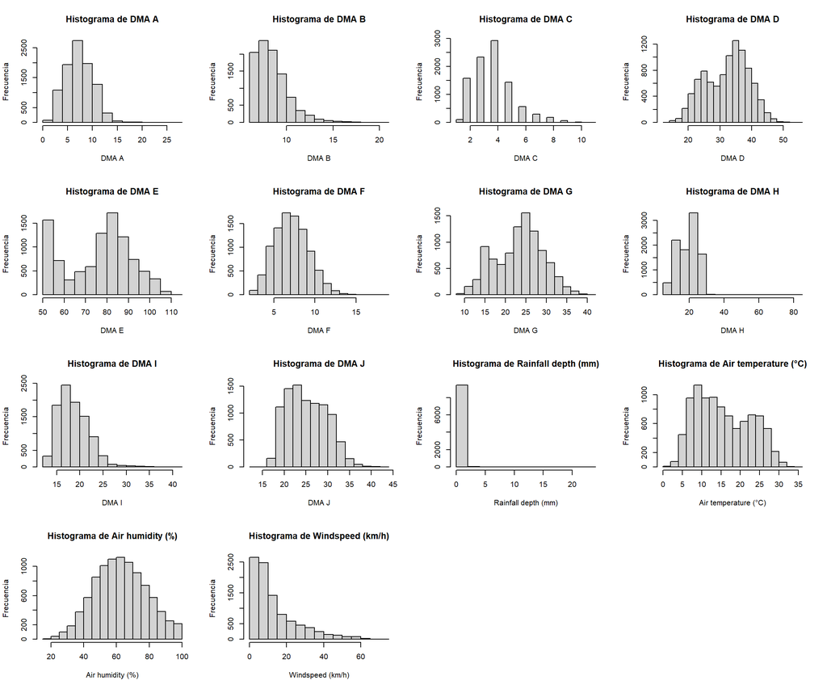

```r
#tomamos las variables númericas
numeric_cols <- sapply(df_data_1, is.numeric)

# Configurar la ventana de trazado para mostrar varios gráficos basados en el número de columnas numéricas
par(mfrow=c(ceiling(sqrt(sum(numeric_cols))), ceiling(sqrt(sum(numeric_cols)))))

# Recorrer cada columna numérica para crear un histograma
for(col in names(df_data_1)[numeric_cols]) {
  hist(df_data_1[[col]], main = paste("Histograma de", col),
       xlab = col, ylab = "Frecuencia")
}

# Restablecer la ventana de trazado a su valor predeterminado
par(mfrow=c(1, 1))
```

Aquí generamos un gráfico para visualizar las distribuciones de nuestras columnas y entender mejor la naturaleza de los datos de cada variable. Observamos que la variable “Rainfall depth” muestra una alta concentración de valores en cero, lo que sugiere que la información disponible para esta variable es limitada

Además, al analizar los datos en general, identificamos posibles valores atípicos (“outliers”) (Para el Bono) en la columna DMA A, particularmente para valores mayores a 15.

## 1.1 Punto 1.2

Se desea identificar si se tiene un patrón dentro de las series de tiempo, para esto se debe usar la técnica de media móvil variando la ventada de tiempo que se usa para cada corrida. Se le indica que debe usar 5 ventanas de tiempo diferentes para compara los resultados y asi poder conluir sobre el patrón en cada serie de tiempo.

### 1.1.1 Media Movil

Vamos a calcular la media movil para 5 periodos de tiempo diferentes, vamos a hacerlo por horas, por meses, con ventanas de tiempo de 1 mes, 2 meses y 5 meses

#### 1.1.1.1 Análisis de corrrelación

Primero vamos a hacer un análisis de correlación para ver que variables tienen una realción más fuerte y, por tanto, podrían ser más relevnates para un análisis más detallado,

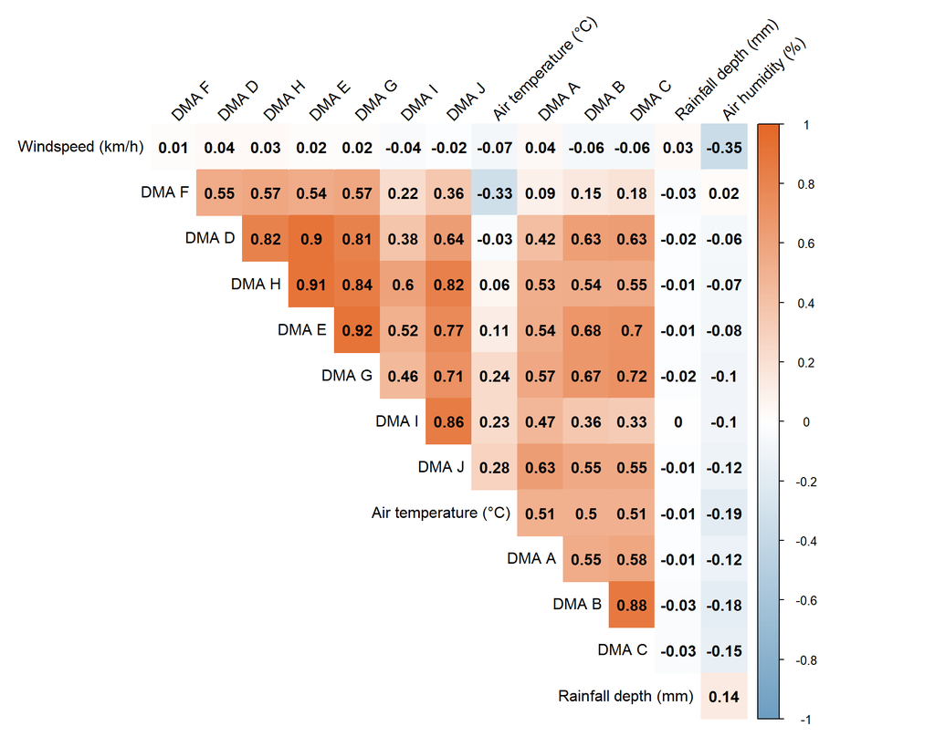

```r
numeric_cols <- sapply(df_data_1, is.numeric)

numeric_df <- df_data_1[, numeric_cols]

# Calcula la matriz de correlación para las columnas numéricas
correlation_matrix <- cor(numeric_df, use = "complete.obs")

# Visualiza la matriz de correlación utilizando corrplot
corrplot(correlation_matrix,
         method = "color",
         type = "upper",
         order = "hclust",
         tl.col = "black",
         tl.srt = 45,
         addCoef.col = "black",
         col = colorRampPalette(c("#6D9EC1", "white", "#E46726"))(200),
         diag = FALSE)
```

Correlaciones Negativas:

La velocidad del viento (Windspeed (km/h)) presenta una correlación negativa con la humedad del aire (Air humidity (%)). Esto sugiere que, en general, a medida que aumenta la velocidad del viento, disminuye la humedad en el aire.

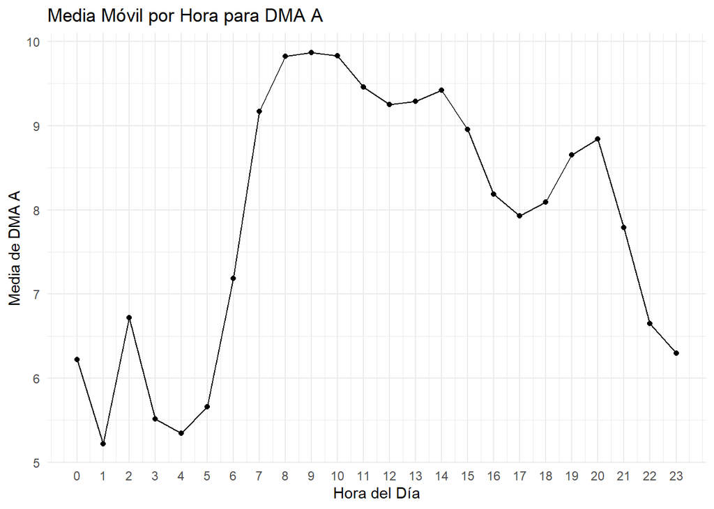

```r
# Convertimos la columna 'Date' a formato POSIXct (fecha y hora) utilizando el formato especificado
df_data_1$Date <- as.POSIXct(df_data_1$Date, format="%d/%m/%Y %H:%M")

# Extraemos la hora del día de la columna 'Date' y la almacenamos en una nueva columna 'Hour'
df_data_1$Hour <- hour(df_data_1$Date)

# Calculamos los promedios por hora para la columna 'DMA A', agrupando por la hora del día
hourly_averages <- df_data_1 %>%
  group_by(Hour) %>%
  summarise(Average_DMA_A = mean(`DMA A`, na.rm = TRUE))

# Creamos un gráfico utilizando ggplot2
ggplot(hourly_averages, aes(x = Hour, y = Average_DMA_A)) +  # Establecemos los ejes x e y y los datos a utilizar
  geom_line() +  # Agregamos una línea que conecta los puntos medios
  geom_point() +  # Agregamos puntos que representan los promedios reales por hora
  labs(title = "Media Móvil por Hora para DMA A", x = "Hora del Día", y = "Media de DMA A") +  # Añadimos etiquetas al gráfico
  scale_x_continuous(breaks = 0:23) +  # Aseguramos que el eje x tenga las 24 horas
  theme_minimal()  # Aplicamos un tema minimalista al gráfico
```

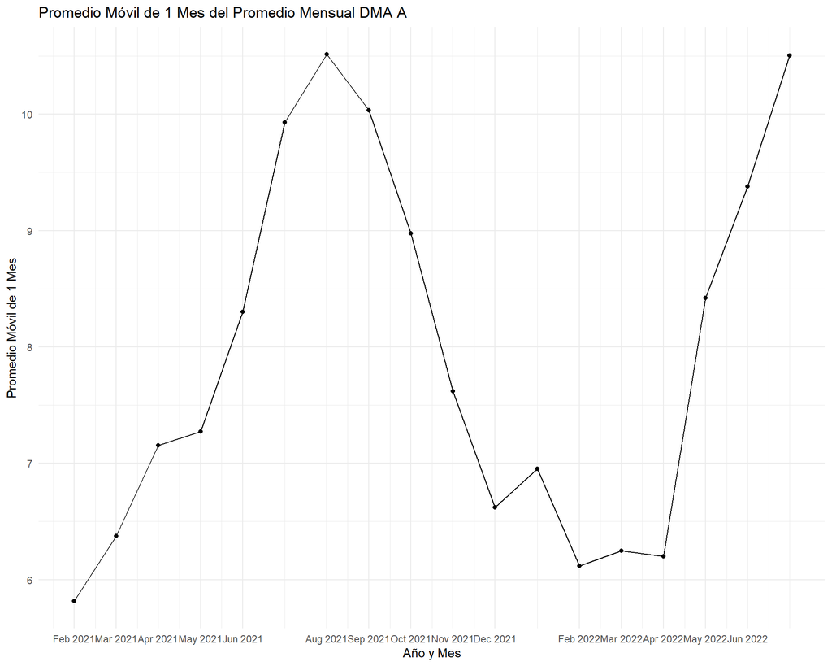

```r
# agregando columnas para el año, el mes y el año y mes combinados (YearMonth)
df_data_3 <- df_data_1 %>%
  mutate(Year = year(Date),               # Extraemos el año de la columna Date
         Month = month(Date),             # Extraemos el mes de la columna Date
         YearMonth = as.yearmon(Date))   # Creamos una columna YearMonth que contiene la fecha en formato yearmon

# Agrupamos por año y mes para calcular el promedio mensual de DMA A
monthly_avg <- df_data_3 %>%
  group_by(YearMonth) %>%
  summarise(MonthlyAvg_DMA_A = mean(`DMA A`, na.rm = TRUE))

# Calculamos el promedio móvil de un mes para los promedios mensuales de DMA A
monthly_avg$MovingAvg_1M <- rollapply(monthly_avg$MonthlyAvg_DMA_A, width = 1, FUN = mean, by.column = TRUE, fill = NA, align = 'right')

# Visualización con ggplot2
ggplot(monthly_avg, aes(x = YearMonth, y = MovingAvg_1M)) +  # Establecemos los ejes x e y y los datos a utilizar
  geom_line() +  # Agregamos una línea que conecta los puntos
  geom_point() +  # Agregamos puntos para representar los promedios móviles
  labs(title = "Promedio Móvil de 1 Mes del Promedio Mensual DMA A",
       x = "Año y Mes",
       y = "Promedio Móvil de 1 Mes") +  # Añadimos etiquetas al gráfico
  scale_x_yearmon(breaks = seq(min(monthly_avg$YearMonth), max(monthly_avg$YearMonth), by = 0.1)) +  # Establecemos los intervalos de los ticks en el eje x
  theme_minimal()  # Aplicamos un tema minimalista al gráfico
```

Aqui también vemos algo interesante y es que existe una mayor demanda de agua en DMA A durante las épocas más cálidas del año. Se registra un aumento en el consumo desde febrero hasta agosto, destacándose julio y agosto como los periodos con los niveles más altos de demanda. Este mismo patrón se repite también para el año 2022, lo que sugiere una correlación entre las estaciones climáticas y el consumo de agua.

[figure not shown]

```r
# Creamos un nuevo dataframe df_data_2 a partir de df_data_1,
# agregando una columna YearMonth que contiene el año y el mes en formato "YYYY-MM",
# luego agrupamos por YearMonth y calculamos el promedio mensual de DMA A
df_data_2 <- df_data_1 %>%
  mutate(YearMonth = format(Date, "%Y-%m")) %>%  # Agregamos una columna YearMonth con el año y mes en formato "YYYY-MM"
  group_by(YearMonth) %>%
  summarise(Monthly_Avg_DMA_A = mean(`DMA A`, na.rm = TRUE)) %>%
  ungroup()  # Eliminamos el agrupamiento para evitar problemas en las siguientes operaciones

# Calculamos las medias móviles para cada uno de los periodos solicitados (1, 5, 10 y 24 meses)
# Cambiamos los nombres de las columnas de medias móviles
df_data_2$MA_1 <- rollapply(df_data_2$Monthly_Avg_DMA_A, width = 1, FUN = mean, fill = NA, align = 'right')
df_data_2$MA_5 <- rollapply(df_data_2$Monthly_Avg_DMA_A, width = 2, FUN = mean, fill = NA, align = 'right')
df_data_2$MA_10 <- rollapply(df_data_2$Monthly_Avg_DMA_A, width = 5, FUN = mean, fill = NA, align = 'right')
df_data_2$MA_24 <- rollapply(df_data_2$Monthly_Avg_DMA_A, width = 10, FUN = mean, fill = NA, align = 'right')

# Convertimos YearMonth de nuevo a un objeto de fecha para la visualización
df_data_2$YearMonth <- as.Date(paste0(df_data_2$YearMonth, "-01"))

# Creamos los gráficos
p1 <- ggplot(df_data_2, aes(x = YearMonth, y = MA_1)) +
  geom_line() +
  ggtitle("Promedio Móvil de 1 Mes de DMA A")

p5 <- ggplot(df_data_2, aes(x = YearMonth, y = MA_5)) +
  geom_line(color = "blue") +
  ggtitle("Promedio Móvil de 5 Meses de DMA A")

p10 <- ggplot(df_data_2, aes(x = YearMonth, y = MA_10)) +
  geom_line(color = "red") +
  ggtitle("Promedio Móvil de 10 Meses de DMA A")

p24 <- ggplot(df_data_2, aes(x = YearMonth, y = MA_24)) +
  geom_line(color = "green") +
  ggtitle("Promedio Móvil de 24 Meses de DMA A")

# Mostramos los gráficos
library(gridExtra)
grid.arrange(p1, p5, p10, p24, ncol = 2)  # Organizamos los gráficos en una cuadrícula de 2 columnas
```

## 1.2 Punto 1.3

Asimimso, se el pide que busque variables que tengan una relación con el consumo de cada una de las áreas mostradas en la tabla 1.

## 1.3 Bono

El dataset inclute posible outliers. Identifique, elimine y compare los resultados obtenidos.

### 1.3.1 Metrica para calcular el K utilizando Kmeans

Para esto utilizamos una gráfica Within-Cluster Sum of Squares WSS y probamos para 10 valores de K, en este caso tenemos la siguiente gráfica.

```r
numeric_data <- df_data_1[, sapply(df_data_1, is.numeric)]

# Definir el número máximo de clusters a considerar
k.max <- 10

# Inicializar un vector para almacenar la suma total de cuadrados dentro de los clusters (WSS)
wss <- numeric(k.max)

# Calcular WSS (Within-Cluster Sum of Squares) para cada valor de k
for (k in 1:k.max) {
  wss[k] <- sum(kmeans(numeric_data, centers = k, nstart = 20)$withinss)
}
```

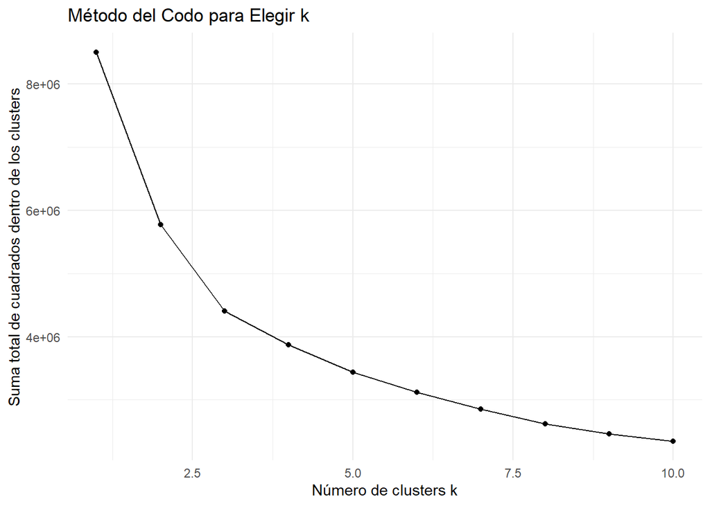

```r
# Crear un dataframe con los valores de k y WSS
k_values <- 1:k.max
ggplot(data.frame(k = k_values, WSS = wss), aes(x = k, y = WSS)) +
  geom_point() +  # Agregar puntos para mostrar los valores de WSS
  geom_line() +   # Conectar los puntos para una mejor visualización
  labs(title = "Método del Codo para Elegir k",
       x = "Número de clusters k",
       y = "Suma total de cuadrados dentro de los clusters") +  # Etiquetas de los ejes
  theme_minimal()  # Aplicar un tema minimalista al gráfico
```

### 1.3.2 K elegido

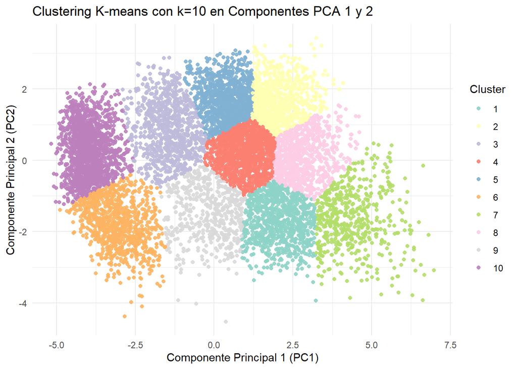

```r
numeric_df <- df_data_1 %>%
  select_if(is.numeric)

# Realizamos PCA (Análisis de Componentes Principales) en los datos numéricos
pca_result <- prcomp(numeric_df, scale. = TRUE)

# Convertimos los resultados de PCA en un dataframe
pca_df <- as.data.frame(pca_result$x)

# Definimos el número de clusters para el algoritmo K-means
k <- 10

# Aplicamos el algoritmo K-means en las dos primeras componentes principales (PC1 y PC2)
km_res <- kmeans(pca_df[, c("PC1", "PC2")], centers = k, nstart = 25)

# Añadimos las asignaciones de cluster al dataframe resultante de PCA
pca_df$cluster <- as.factor(km_res$cluster)

# Creamos un gráfico utilizando ggplot2
ggplot(pca_df, aes(x = PC1, y = PC2, color = cluster)) +  # Definimos las variables x, y y color
  geom_point(alpha = 0.9) +  # Usamos alpha para ajustar la opacidad de los puntos, mejorando la legibilidad del gráfico
  scale_color_brewer(palette = "Set3") +  # Usamos una paleta de colores distintiva para mayor claridad
  labs(title = "Clustering K-means con k=10 en Componentes PCA 1 y 2",
       x = "Componente Principal 1 (PC1)",
       y = "Componente Principal 2 (PC2)",
       color = "Cluster") +  # Establecemos el título de la leyenda correctamente
  theme_minimal()  # Utilizamos un tema minimalista para un aspecto más limpio
```

```r
print(summary(pca_result)$importance[2, 1:2])
```

```
##     PC1     PC2
## 0.44944 0.12979
```

```r
centroids <- aggregate(cbind(PC1, PC2) ~ cluster, data = pca_df, FUN = mean)

# Unimos los centroides de nuevo al dataframe original para calcular las distancias
pca_df_with_centroids <- merge(pca_df, centroids, by = "cluster", suffixes = c("", "_centroid"))

# Calculamos la distancia euclidiana desde cada punto hasta su centroide de cluster
pca_df_with_centroids$distance <- sqrt((pca_df_with_centroids$PC1 - pca_df_with_centroids$PC1_centroid)^2 +
                                       (pca_df_with_centroids$PC2 - pca_df_with_centroids$PC2_centroid)^2)

# Definimos el criterio para los valores atípicos. Distancias mayores a 1.5 desviaciones estándar de la distancia media para cada cluster
pca_df_with_centroids <- pca_df_with_centroids %>%
  group_by(cluster) %>%
  mutate(mean_distance = mean(distance), sd_distance = sd(distance)) %>%
  ungroup() %>%
  mutate(outlier = ifelse(distance > mean_distance + 1.5*sd_distance, TRUE, FALSE))

# Filtramos los valores atípicos
df_no_outliers <- filter(pca_df_with_centroids, outlier == FALSE)
```

Tras identificar nuestros clusters, procedemos a calcular los centroides de cada uno para determinar qué valores se desvían significativamente dentro de cada grupo. Utilizamos un criterio de 1.5 desviaciones estándar alrededor del centroide de cada cluster para identificar y excluir los outliers de nuestro análisis. Esto nos permite depurar nuestro conjunto de datos, eliminando elementos atípicos que podrían distorsionar los resultados. Como resultado, generamos un nuevo dataframe, denominado df_no_outliers.

### 1.3.3 Resultdos Sin Outliers

Ahora vamos a hacer el análisis sin outliers, primero veamos la cantidad de Outliers que quitamos de nuestros datos.

```r
# Obtener las dimensiones del dataframe original y del dataframe sin valores atípicos
dimensions_df <- dim(df_data_1)
dimensions_no_outliers <- dim(df_no_outliers)

# Calcular la diferencia en dimensiones entre ambos dataframes
difference <- dimensions_df - dimensions_no_outliers

# Imprimir las dimensiones y la diferencia en una sola declaración
cat("Dimensiones de df_data_1:", paste(dimensions_df, collapse = "x"), "\n",
    "Dimensiones de df_no_outliers:", paste(dimensions_no_outliers, collapse = "x"), "\n",
    "Diferencia (valores atípicos eliminados):", paste(difference, collapse = "x"), "\n")
```

```
## Dimensiones de df_data_1: 9502x16
##  Dimensiones de df_no_outliers: 8889x22
##  Diferencia (valores atípicos eliminados): 613x-6
```

Observamos que se han eliminado 613 valores atípicos de nuestros datos. De los 9500 datos originales, aproximadamente el 6.45% (613 valores atípicos) han sido eliminados. Es importante tener en cuenta que, al analizar específicamente la columna DMA A, se observa que la eliminación de valores atípicos parece estar sesgada hacia datos por encima del valor 15, como se evidenció en el histograma previamente analizado.

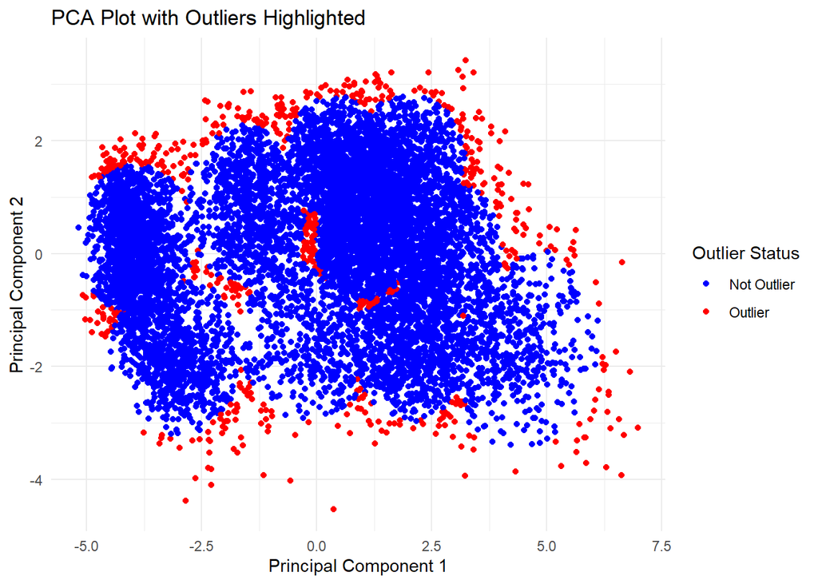

```r
# Plot PCA with outliers highlighted
ggplot(pca_df_with_centroids, aes(x = PC1, y = PC2, color = outlier)) +
  geom_point() +
  scale_color_manual(values = c("blue", "red"), labels = c("Not Outlier", "Outlier")) +
  labs(title = "PCA Plot with Outliers Highlighted",
       x = "Principal Component 1",
       y = "Principal Component 2",
       color = "Outlier Status") +
  theme_minimal()
```

Aquí se muestran los valores atípicos que hemos eliminado de nuestros datos. Observamos que estos valores atípicos representan prácticamente las fronteras de cada cluster identificadas anteriormente, es decir, las partes más alejadas de sus respectivos centros. En este caso, hemos utilizado un criterio de eliminación que considera valores que están aproximadamente a más de 1.5 desviaciones estándar de la media.

```r
data_2 <- df_data_1[, c('Date', 'DMA A', 'DMA B', 'DMA C', 'DMA D', 'DMA E', 'DMA F', 'DMA G', 'DMA H', 'DMA I', 'DMA J',
                        'Rainfall depth (mm)', 'Air temperature (°C)', 'Air humidity (%)', 'Windspeed (km/h)')]

# Convierte los índices de las filas seleccionadas sin valores atípicos a numéricos
row_indices <- as.numeric(rownames(df_no_outliers))

# Utilizamos los indices para seleccionar las mismas filas del dataframe original
df_no_outliers <- data_2[row_indices, ]
```

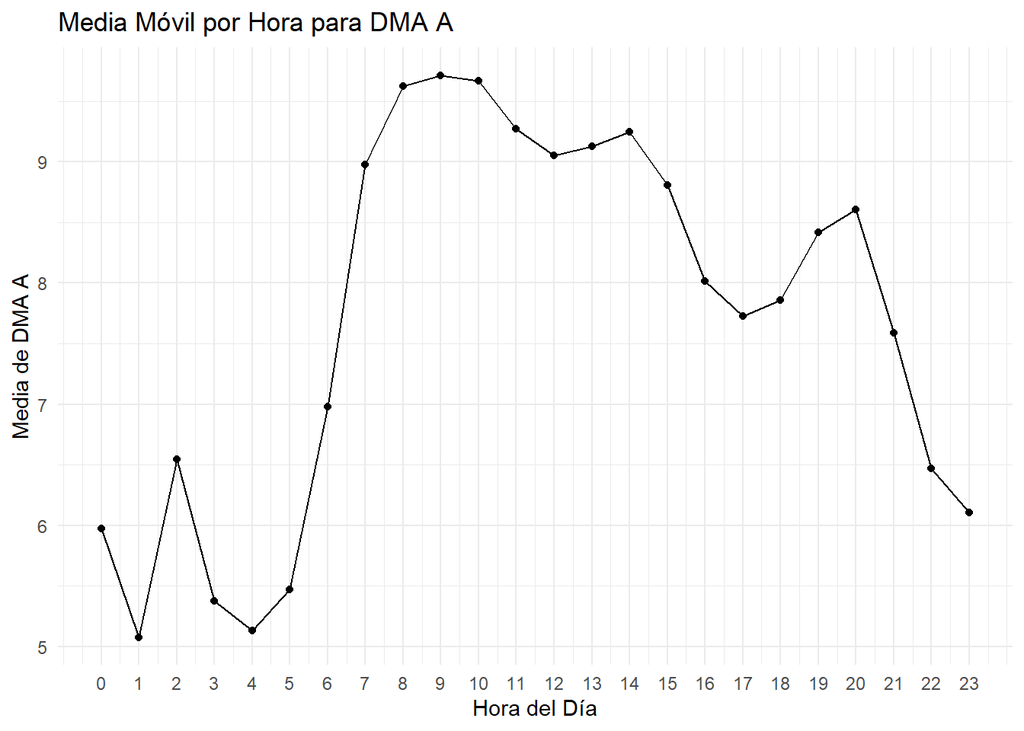

```r
df_no_outliers$Date <- as.POSIXct(df_no_outliers$Date, format="%d/%m/%Y %H:%M")

# Extraemos la hora del día de la columna 'Date'
df_no_outliers$Hour <- hour(df_no_outliers$Date)

# Calculamos el promedio por hora de la columna 'DMA A'
hourly_averages <- df_no_outliers %>%
  group_by(Hour) %>%
  summarise(Average_DMA_A = mean(`DMA A`, na.rm = TRUE))

# Creamos el gráfico utilizando ggplot2
ggplot(hourly_averages, aes(x = Hour, y = Average_DMA_A)) +
  geom_line() +  # Línea que conecta los puntos medios
  geom_point() +  # Puntos que representan los promedios reales por hora
  labs(title = "Media Móvil por Hora para DMA A", x = "Hora del Día", y = "Media de DMA A") +
  scale_x_continuous(breaks = 0:23) +  # Aseguramos que el eje x tenga las 24 horas
  theme_minimal()  # Tema minimalista para el gráfico
```

Observamos que en la gráfica de horas, la visualización es un poco más clara, pero en general, no se observan diferencias muy notables con los datos sin outliers. La media no parece verse afectada significativamente en este caso.

[figure not shown]

```r
# Agregamos la columna YearMonth, que contiene el año y el mes de la fecha en formato "%Y-%m"
# Calculamos el promedio mensual de DMA A para cada YearMonth
# Finalmente, desagrupamos el dataframe resultante
df_data_2 <- df_no_outliers %>%
  mutate(YearMonth = format(Date, "%Y-%m")) %>%
  group_by(YearMonth) %>%
  summarise(Monthly_Avg_DMA_A = mean(`DMA A`, na.rm = TRUE)) %>%
  ungroup()

# Calculamos las medias móviles para cada uno de los periodos solicitados (1, 5, 10 y 24 meses)
# Cambiamos los nombres de las columnas de medias móviles
df_data_2$MA_1 <- rollapply(df_data_2$Monthly_Avg_DMA_A, width = 1, FUN = mean, fill = NA, align = 'right')
df_data_2$MA_5 <- rollapply(df_data_2$Monthly_Avg_DMA_A, width = 2, FUN = mean, fill = NA, align = 'right')
df_data_2$MA_10 <- rollapply(df_data_2$Monthly_Avg_DMA_A, width = 5, FUN = mean, fill = NA, align = 'right')
df_data_2$MA_24 <- rollapply(df_data_2$Monthly_Avg_DMA_A, width = 10, FUN = mean, fill = NA, align = 'right')

# Convertimos la columna YearMonth de vuelta a un objeto de fecha para su visualización
df_data_2$YearMonth <- as.Date(paste0(df_data_2$YearMonth, "-01"))

# Creamos los gráficos para cada una de las medias móviles (1, 5, 10 y 24 meses)
p1 <- ggplot(df_data_2, aes(x = YearMonth, y = MA_1)) +
  geom_line() +
  ggtitle("Media Móvil de 1 Mes de DMA A")

p5 <- ggplot(df_data_2, aes(x = YearMonth, y = MA_5)) +
  geom_line(color = "blue") +
  ggtitle("Media Móvil de 5 Meses de DMA A")

p10 <- ggplot(df_data_2, aes(x = YearMonth, y = MA_10)) +
  geom_line(color = "red") +
  ggtitle("Media Móvil de 10 Meses de DMA A")

p24 <- ggplot(df_data_2, aes(x = YearMonth, y = MA_24)) +
  geom_line(color = "green") +
  ggtitle("Media Móvil de 24 Meses de DMA A")

# Mostramos los gráficos en una disposición de cuadrícula
library(gridExtra)
grid.arrange(p1, p5, p10, p24, ncol = 2)
```

Cuando observamos las gráficas de los intervalos de medias móviles para DMA A después de eliminar los outliers, no vemos una diferencia significativa. Esto podría sugerir que los outliers no estaban ejerciendo una influencia significativa en la tendencia general de los datos. Sin embargo, sería valioso explorar esta hipótesis también para columnas con outliers más pronunciados, ya que podrían tener un impacto más significativo en los resultados.

# 2 Punto

Spotify es una empresa para la reproducción de música vía streaming que se ha venido consolidando como una de las plataformas más relevantes a nivel mundial. Considere que usted se ha conectado con la API de Spotify y ha podido descargar la información de la banda “Los Planetas”, una banda española de indie rock que ha estado activa desde 1993 Dentro de la información disponible descargada se encuentra nombres de canciones, nombres de los álbumes, duración o tempo. Adicionalmente, tiene unos descriptores en términos a qué tan positiva, bailable, enérgica, acústica, instrumental o en vivo fue cada canción. Con base en esta base de datos, se le pide lo siguiente:

## 2.1 1.

Realice un análisis de PCA que permita describir el tipo de canciones. Por ejemplo, ¿Cómo se relaciona las canciones bailables con las de tipo instrumental? ¿Las canciones con larga duración con las enérgicas? ¿Las canciones en vivo con las acústicas?

Primero carga y descriptivo de que trae la base de datos

```r
# Establece el directorio de trabajo
#setwd("C:/Users/O004607/Documents/Maestria/SegundoSemestre/MineriaDatos/Clase4/")

# Carga el archivo de datos 'canciones.RData'
load("canciones.RData")

# Muestra las primeras filas de 'canciones'
head(canciones)
```

```
## # A tibble: 6 × 13
##   id             name  album_id album duration tempo valence danceability energy
##   <chr>          <chr> <chr>    <chr>    <dbl> <dbl>   <dbl>        <dbl>  <dbl>
## 1 02jXZfT8IjNmd… Isla… 1khQHoH… Zona…     423.  118.    12.8         36.4   51.6
## 2 0e8EpWgw3MmmY… La M… 4qNag8c… Pop       343   133.    53           25.5   93
## 3 0eOEe1eGVaxNh… Corr… 2yr7ln7… Encu…     278.  123.    54.7         52.3   78.3
## 4 0h84bQDr2i0uL… Entr… 165G43f… La L…     163.  138.    39.6         34.2   65.7
## 5 0JJFhZAHf8p5Q… 8     4qNag8c… Pop       236.  138.    73.5         48.3   85.7
## 6 0K7drrEz6pKMw… 124   26hZrPW… Los …     246.  112     82.2         36.6   94.9
## # ℹ 4 more variables: acousticness <dbl>, instrumentalness <dbl>,
## #   liveness <dbl>, speechiness <dbl>
```

Observando el head de los datos vemos que

id: Identificador único de la canción.

name: Nombre de la canción.

album_id: Identificador único del álbum al que pertenece la canción.

album: Nombre del álbum.

duration: Duración de la canción en segundos.

tempo: Tempo de la canción en golpes por minuto (BPM).

valence: Una medida de la positividad musical, que describe la musicalidad de las canciones en términos de ser más positivas o alegres.

danceability: Una medida de cuán adecuada es una canción para bailar basada en una combinación de elementos musicales incluyendo el tempo, estabilidad del ritmo, fuerza del beat, y regularidad general.

energy: Una medida que representa la intensidad y actividad percibida de una canción.

acousticness: Una medida que indica cuán acústica es una canción.

instrumentalness: Una medida que indica qué tan instrumental es una canción.

liveness: Detecta la presencia de una audiencia en la grabación. Altos valores para este atributo indican que la canción fue realizada en vivo.

speechiness: Detecta la presencia de palabras habladas en una canción. Un valor más alto significa que la canción contiene más palabras habladas.

```r
# Obtiene y muestra las dimensiones de 'canciones' (filas, columnas)
dim(canciones)
```

```
## [1] 109  13
```

El archivo contiene datos con 109 filas y 13 columnas. Hay información sobre 109 canciones, cada una descrita por 13 atributos.

```r
# Muestra un resumen estadístico de 'canciones'

summary(canciones)
```

```
##       id                name             album_id            album
##  Length:109         Length:109         Length:109         Length:109
##  Class :character   Class :character   Class :character   Class :character
##  Mode  :character   Mode  :character   Mode  :character   Mode  :character
##
##
##
##     duration         tempo          valence       danceability
##  Min.   : 88.4   Min.   : 59.7   Min.   : 4.70   Min.   : 6.80
##  1st Qu.:203.8   1st Qu.:107.6   1st Qu.:27.90   1st Qu.:24.50
##  Median :243.7   Median :122.8   Median :50.10   Median :34.40
##  Mean   :267.1   Mean   :127.8   Mean   :49.88   Mean   :33.43
##  3rd Qu.:296.5   3rd Qu.:143.3   3rd Qu.:70.10   3rd Qu.:41.70
##  Max.   :621.7   Max.   :215.1   Max.   :96.70   Max.   :75.00
##      energy       acousticness    instrumentalness    liveness
##  Min.   :21.90   Min.   : 0.000   Min.   : 0.00    Min.   : 4.90
##  1st Qu.:62.90   1st Qu.: 0.000   1st Qu.: 1.80    1st Qu.:11.40
##  Median :76.60   Median : 0.700   Median :21.00    Median :16.40
##  Mean   :72.76   Mean   : 6.267   Mean   :37.13    Mean   :23.32
##  3rd Qu.:86.50   3rd Qu.: 5.000   3rd Qu.:73.80    3rd Qu.:30.20
##  Max.   :97.20   Max.   :78.700   Max.   :92.70    Max.   :91.20
##   speechiness
##  Min.   :2.700
##  1st Qu.:3.100
##  Median :3.800
##  Mean   :4.228
##  3rd Qu.:4.800
##  Max.   :9.000
```

se puede inferir para cada variable que

Duration: Las canciones tienen una duración que varía considerablemente, con un rango de 88.4 a 621.7 segundos.

Tempo: El tempo fluctúa entre 59.7 y 215.1 BPM, mostrando una amplia gama de ritmos.

Valence (Positivity): Con valores de 4.70 a 96.70, la valencia muestra que las canciones abarcan un espectro emocional amplio,

Danceability: La bailableidad varía de 6.80 a 75.00, algunas canciones son más adecuadas para bailar que otras.

Energy: Los niveles de energía oscilan entre 21.90 y 97.20, la banda produce tanto música tranquila como pistas llenas de vigor.

Acousticness: La acústica tiene un rango de 0.0 a 78.7.

Instrumentalness: Con valores de 0 a 92.70..

Liveness: La vivacidad varía de 4.90 a 91.20.

Speechiness: La hablabilidad tiene un rango de 2.7 a 9.0.

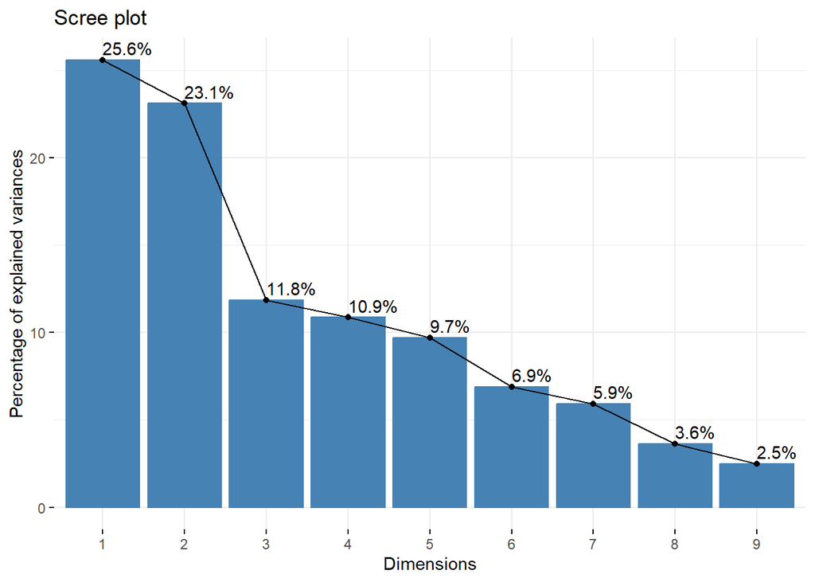

```r
# Cargar paquetes necesarios para PCA y visualización
library(FactoMineR)
library(factoextra)

# Seleccionar variables numéricas de 'canciones' para el análisis PCA
datos_pca <- canciones[, c("duration", "tempo", "valence", "danceability", "energy", "acousticness", "instrumentalness", "liveness", "speechiness")]

# Ejecutar PCA, escalando las variables para igualar su varianza y sin generar gráficos automáticamente
pca_result <- PCA(datos_pca, scale.unit = TRUE, graph = FALSE)

# Visualizar los eigenvalores para evaluar la cantidad de componentes principales a retener
fviz_eig(pca_result, addlabels = TRUE)  # Gráfico de eigenvalores
```

```r
eig.val <- get_eigenvalue(pca_result)  # Obtener y mostrar eigenvalores

# Extraer y mostrar las variables y su contribución al PCA
var <- get_pca_var(pca_result)  # Obtener información de las variables en el PCA
var
```

```
## Principal Component Analysis Results for variables
##  ===================================================
##   Name       Description
## 1 "$coord"   "Coordinates for the variables"
## 2 "$cor"     "Correlations between variables and dimensions"
## 3 "$cos2"    "Cos2 for the variables"
## 4 "$contrib" "contributions of the variables"
```

```r
# Ejecutar PCA reteniendo las primeras 4 componentes principales, escalando variables para igualar su varianza, sin generar gráficos automáticamente

pca_result <- PCA(datos_pca, scale.unit = TRUE, ncp = 4, graph = FALSE)
```

### 2.1.1 Primer vs segundo eje

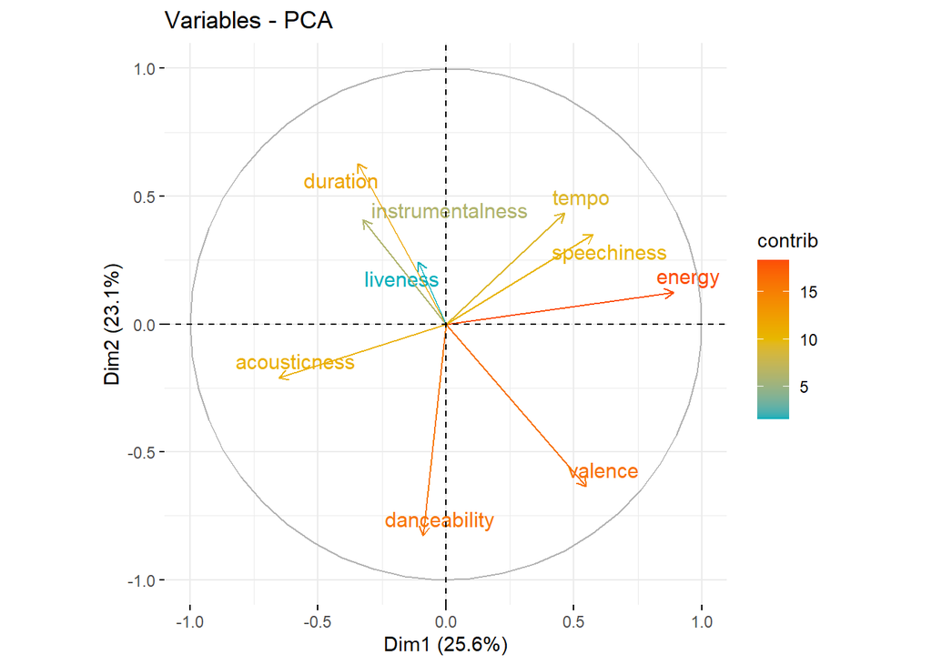

```r
# Visualizar variables del PCA por contribución en las dos primeras dimensiones
# Colorea las variables según su contribución, usa un gradiente de color, y evita la superposición de texto
fviz_pca_var(pca_result, col.var = "contrib",
             gradient.cols = c("#00AFBB", "#E7B800", "#FC4E07"),
             repel = TRUE,
             axes = c(1, 2))
```

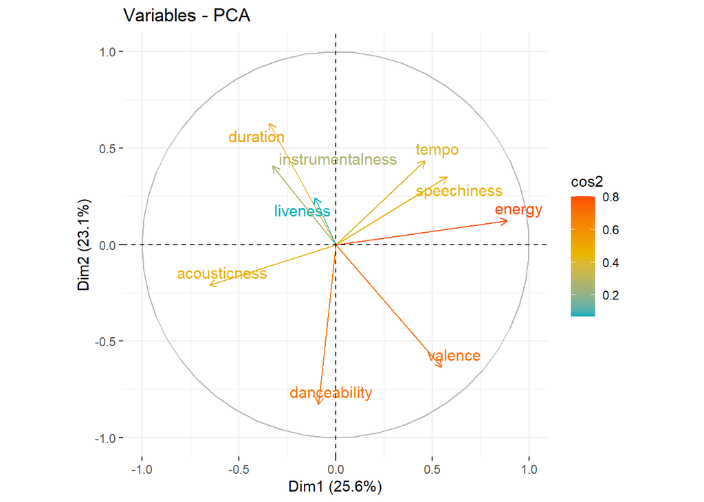

```r
# Visualizar variables del PCA por calidad de representación (cos2) en las dos primeras dimensiones
# Colorea las variables según su cos2, usa un gradiente de color, y evita la superposición de texto
fviz_pca_var(pca_result, col.var = "cos2",
             gradient.cols = c("#00AFBB", "#E7B800", "#FC4E07"),
             repel = TRUE,
             axes = c(1, 2))
```

Es importante tener en cuenta tanto la contribución al eje como la calidad de respresentación dada por el cos2. Observamos que las variables que más aportan a estas dos dimensiones son energia, valence y danceability

Destacan las relaciones:

Energía y Tempo: Estas variables están alineadas en la misma dirección en la primera dimensión, lo que indica que las canciones con un tempo más rápido tienden a ser percibidas como más enérgicas. .

Energia y acousticness: Se encuentran en direcciones opuestas en la dimension 1, indicando que las canciones mas energicas son menos acusticas.

Valence y duration: Se encuentran en direcciones opuestas en el eje dos, lo que nos podría decir que a mayor duración de una canción es menos la sensación de positividad,

### 2.1.2 Primer eje vs tercer eje

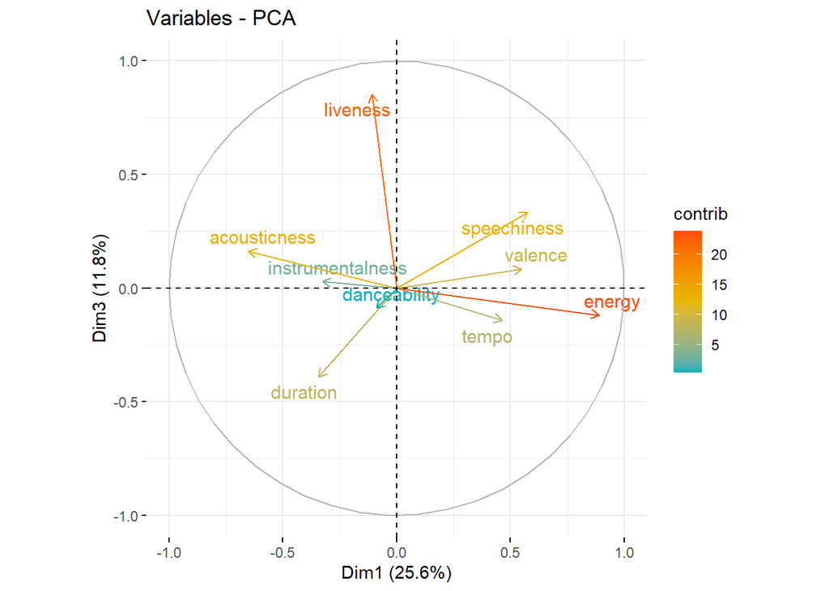

```r
fviz_pca_var(pca_result, col.var = "contrib",
             gradient.cols = c("#00AFBB", "#E7B800", "#FC4E07"),
             repel = TRUE,
             axes = c(1, 3))
```

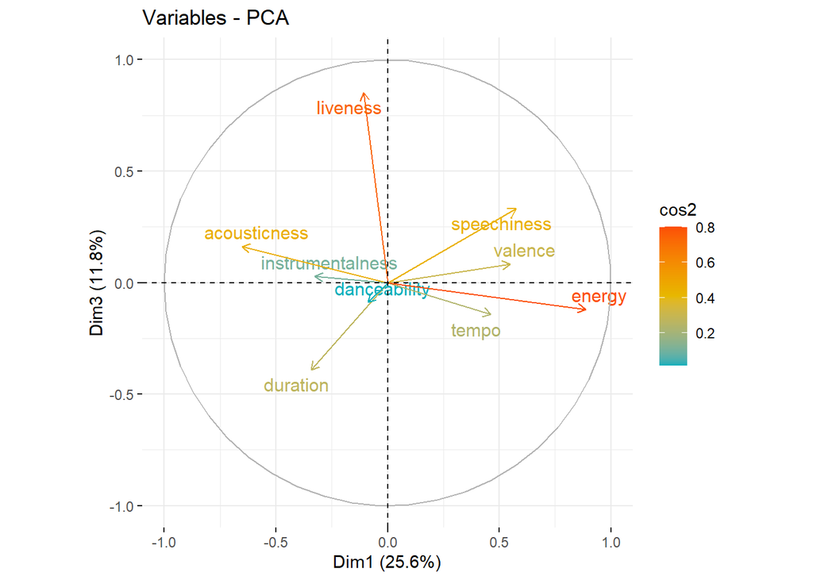

```r
fviz_pca_var(pca_result, col.var = "cos2",
             gradient.cols = c("#00AFBB", "#E7B800", "#FC4E07"),
             repel = TRUE,
             axes = c(1, 3)
)
```

Speechiness y Liveness (vivacidad): Se observa una proximidad entre speechiness y liveness en Dim3. Esto puede indicar que las canciones con mayor contenido hablado también pueden ser aquellas que tienen una mayor probabilidad de ser grabaciones en vivo o de contener elementos en vivo, como aplausos o interacciones con la audiencia.

### 2.1.3 Primer eje vs cuarto eje

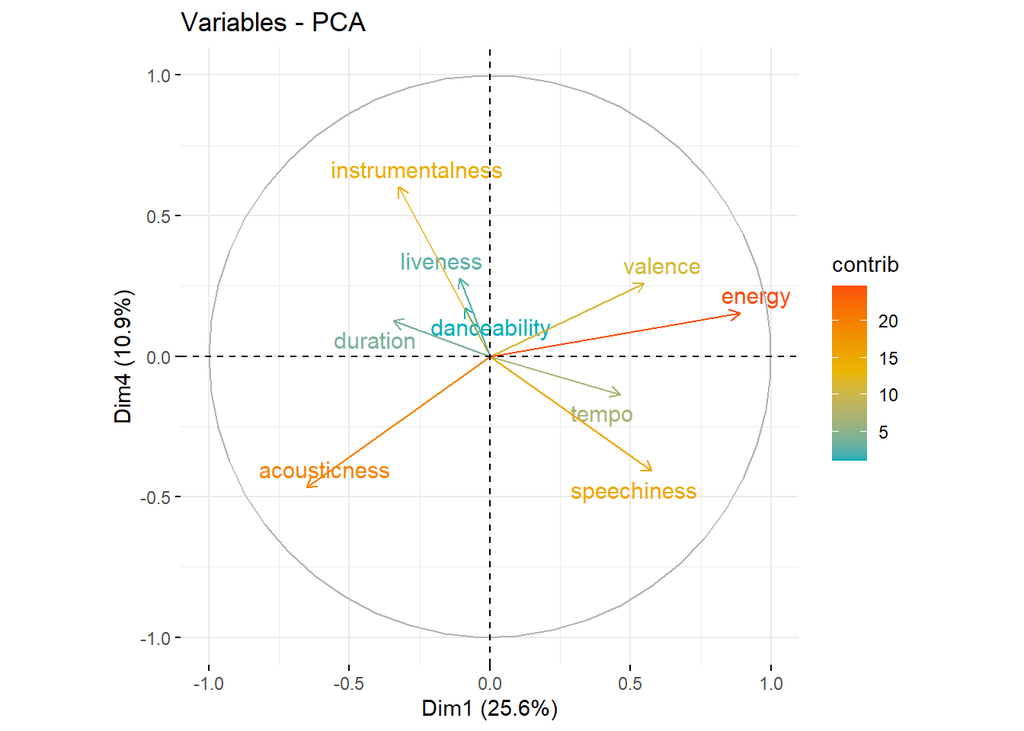

```r
fviz_pca_var(pca_result, col.var = "contrib",
             gradient.cols = c("#00AFBB", "#E7B800", "#FC4E07"),
             repel = TRUE,
             axes = c(1, 4))
```

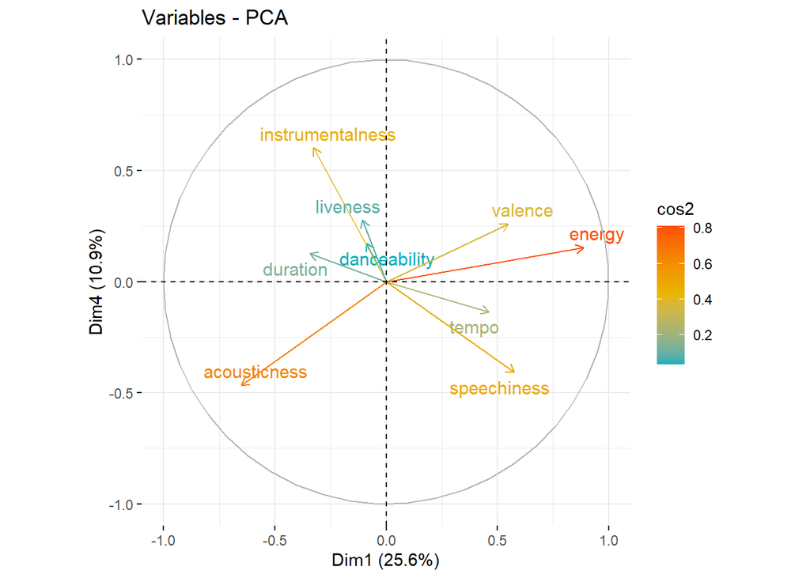

```r
fviz_pca_var(pca_result, col.var = "cos2",
             gradient.cols = c("#00AFBB", "#E7B800", "#FC4E07"),
             repel = TRUE,
             axes = c(1, 4)
)
```

Instrumentales y speechiness: Las canciones que tienen un alto grado de speechiness probablemente serán bajas en instrumentalness. Indicando que las canciones instrumentales tendrían menor cantidad de palabras habladas.

Acousticness y valence: Las canciones con alta acústica no tienden a ser las más positivas o alegres, y las canciones con alta valencia no son necesariamente acústicas.

### 2.1.4 segundo eje vs tercer eje

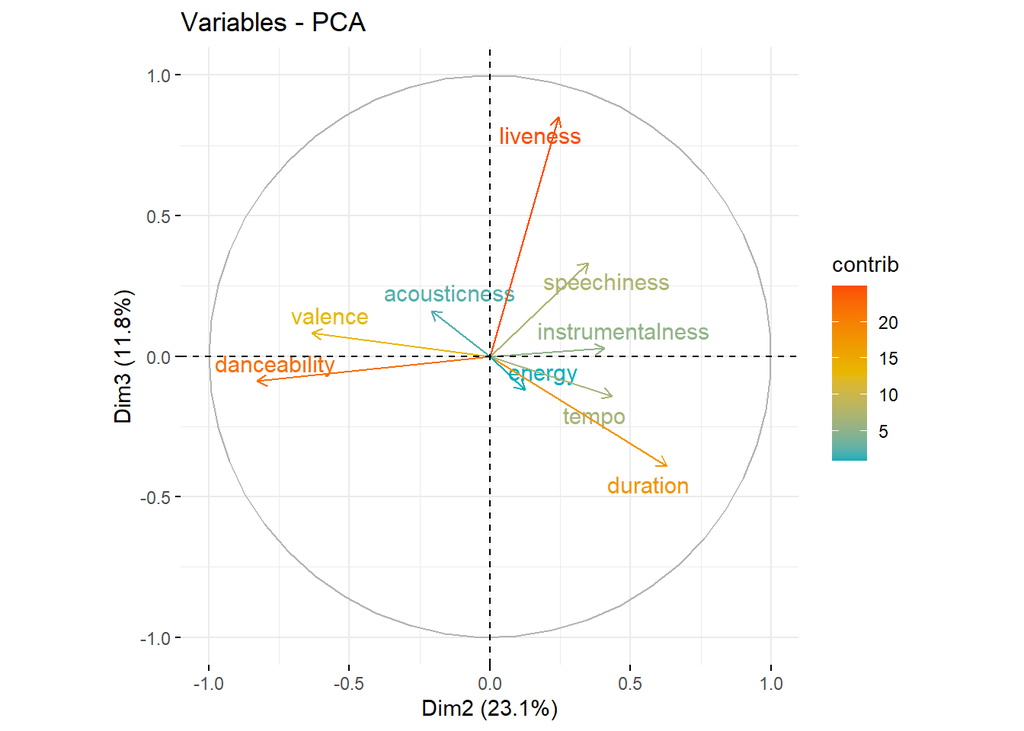

```r
fviz_pca_var(pca_result, col.var = "contrib",
             gradient.cols = c("#00AFBB", "#E7B800", "#FC4E07"),
             repel = TRUE,
             axes = c(2, 3))
```

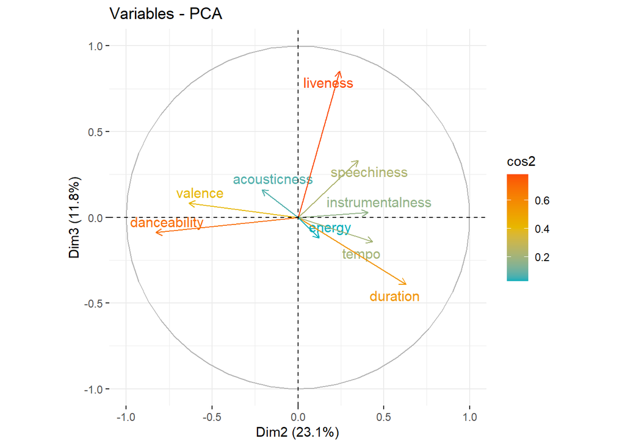

```r
fviz_pca_var(pca_result, col.var = "cos2",
             gradient.cols = c("#00AFBB", "#E7B800", "#FC4E07"),
             repel = TRUE,
             axes = c(2, 3)
)
```

Liveness (Vivacidad) y Speechiness (Hablabilidad): Estas variables, ubicadas en la parte superior del gráfico y más cerca de la Dim3, sugieren que las canciones con mayor presencia de audiencia en vivo o elementos de grabación en vivo tienden a tener más contenido hablado.

### 2.1.5 segundo eje vs cuarto eje

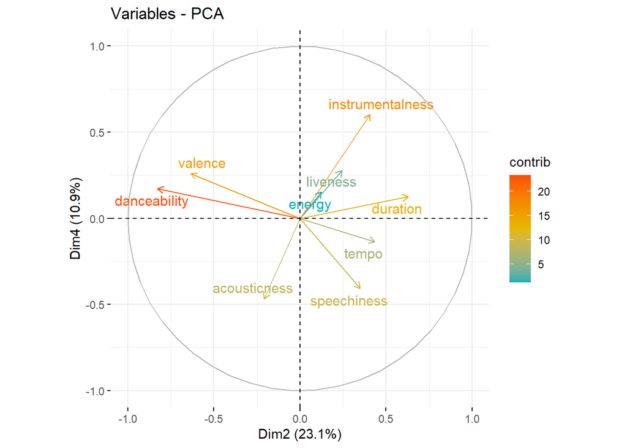

```r
fviz_pca_var(pca_result, col.var = "contrib",
             gradient.cols = c("#00AFBB", "#E7B800", "#FC4E07"),
             repel = TRUE,
             axes = c(2, 4))
```

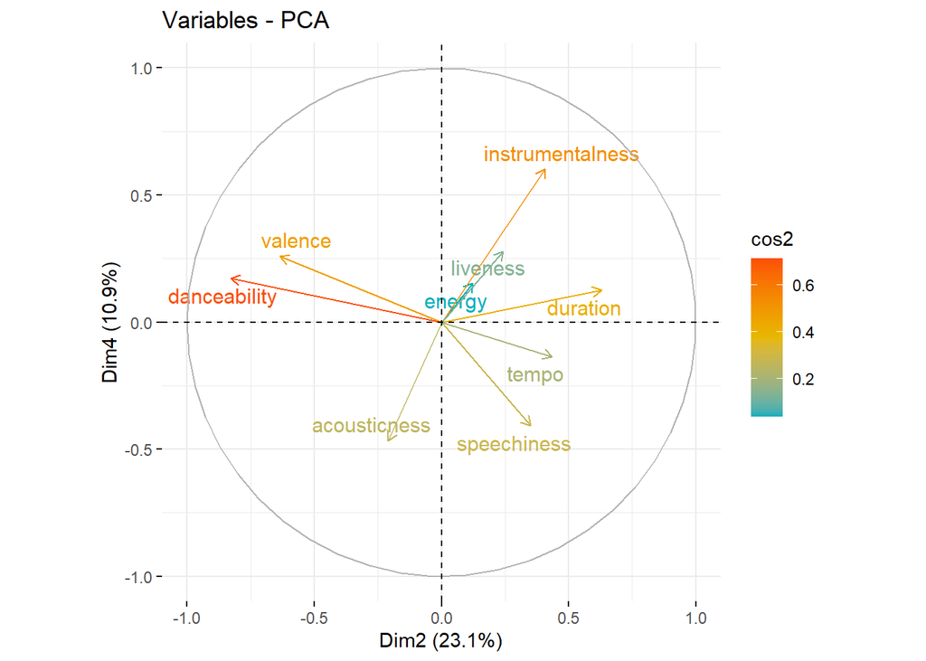

```r
fviz_pca_var(pca_result, col.var = "cos2",
             gradient.cols = c("#00AFBB", "#E7B800", "#FC4E07"),
             repel = TRUE,
             axes = c(2, 4)
)
```

No se infieren cosas nuevas a las anteriores mencionadas.

### 2.1.6 tercer eje vs cuarto eje

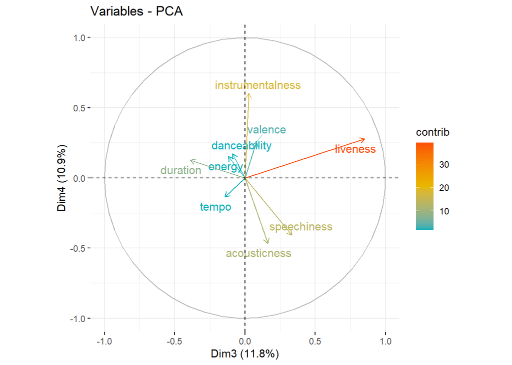

```r
fviz_pca_var(pca_result, col.var = "contrib",
             gradient.cols = c("#00AFBB", "#E7B800", "#FC4E07"),
             repel = TRUE,
             axes = c(3, 4))
```

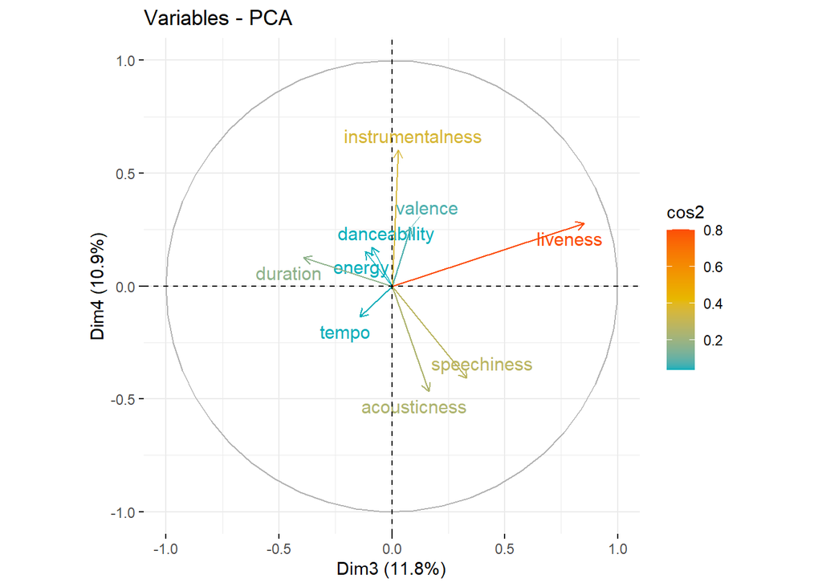

```r
fviz_pca_var(pca_result, col.var = "cos2",
             gradient.cols = c("#00AFBB", "#E7B800", "#FC4E07"),
             repel = TRUE,
             axes = c(3, 4)
)
```

Se destaca que para la dimensión 3 es muy importante la caracteristica dada por liveness.

## 2.2 2.

Con base en las nubes de individuos y variables, describan los álbumes de esta banda. ¿Cuáles podrían ser más enérgicos, positivos, entre otras características?

### 2.2.1 Primer vs segundo eje

```r
# Cargar librerías necesarias para visualización
library(FactoMineR)
library(factoextra)
library(ggrepel)
library(ggplot2)

# Seleccionar datos para PCA excluyendo las primeras 3 columnas
datos_para_pca <- canciones[, -(1:3)]

# Mostrar dimensiones de los datos seleccionados
dim(datos_para_pca)
```

```
## [1] 109  10
```

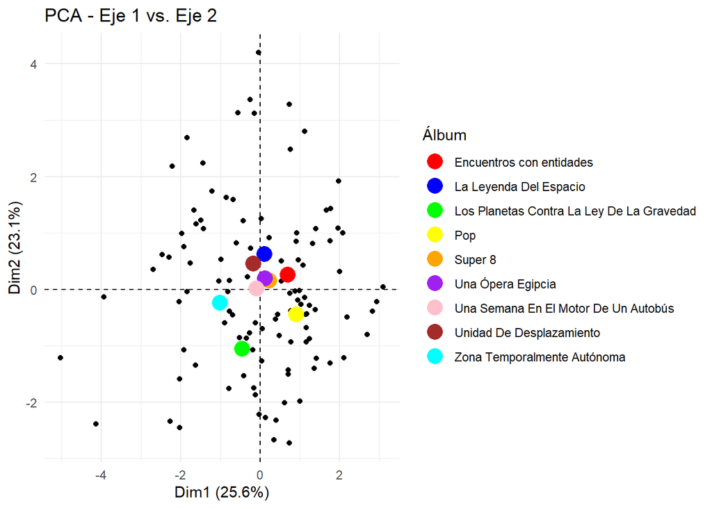

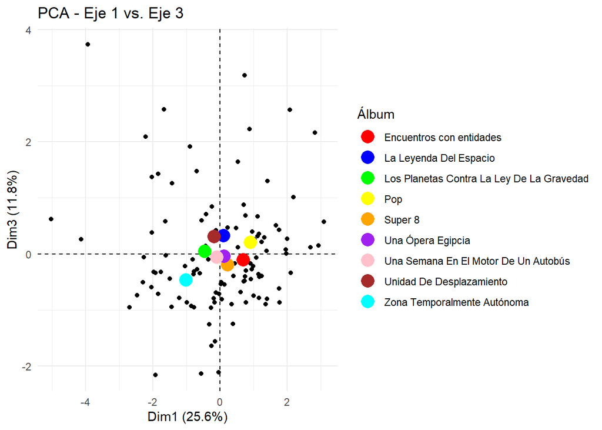

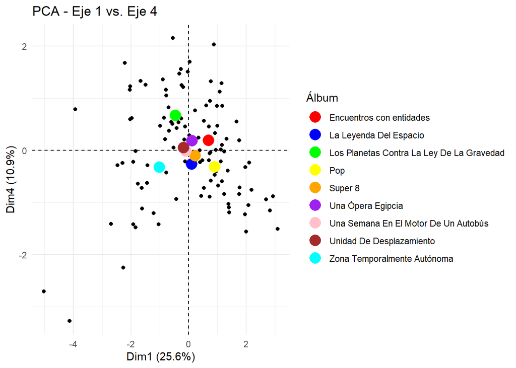

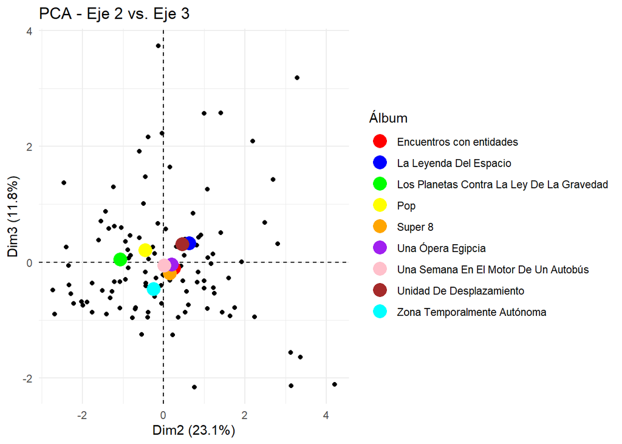

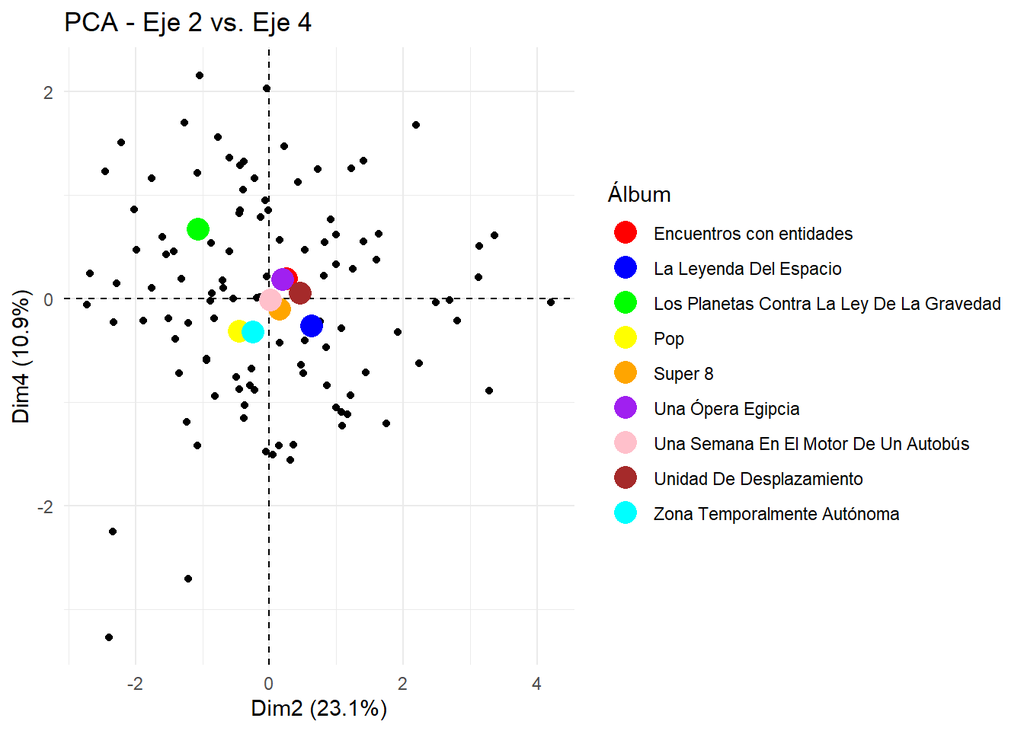

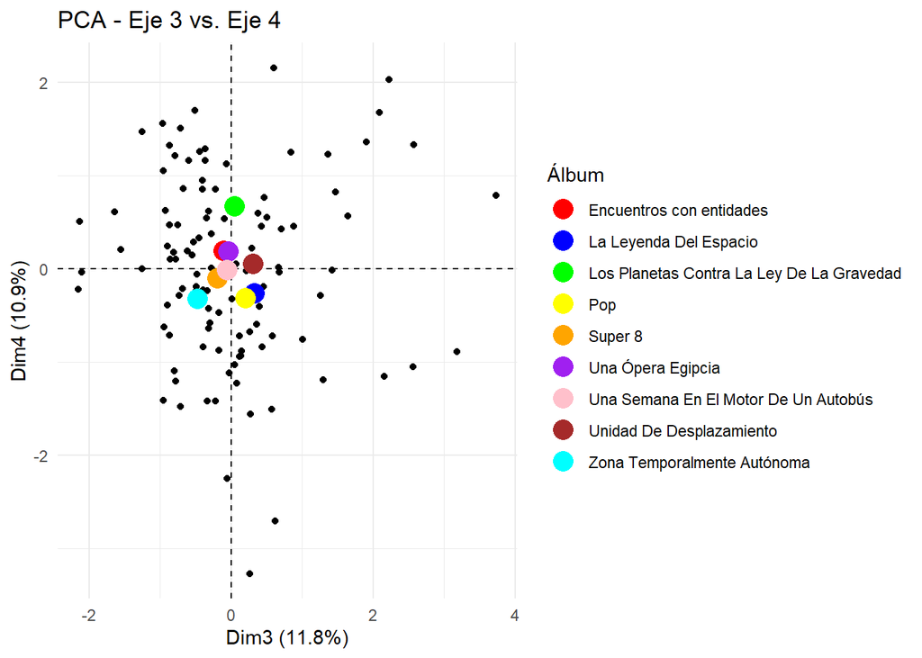

```r
# Realizar PCA con la primera columna como variable cualitativa, sin gráficos y escalando variables
res <- PCA(datos_para_pca, quali.sup = 1, graph = FALSE, scale.unit = TRUE, ncp = 4)

# Crear dataframe con coordenadas de la variable cualitativa (supuestamente álbumes) y añadir nombres de álbumes
album_data <- as.data.frame(res$quali.sup$coord)
album_data$album <- rownames(album_data)

# Definir colores para cada álbum
colors_for_albums <- c("red", "blue", "green", "yellow", "orange", "purple", "pink", "brown", "cyan")

# Generar y mostrar gráficos PCA para combinaciones de las primeras 4 componentes, coloreando por álbum
for(i in 1:3) {
  for(j in (i+1):4) {
    p <- fviz_pca_ind(res, geom.ind = "point", repel = TRUE, axes = c(i, j)) +
      theme_minimal() +
      geom_point(data = album_data, aes_string(x = paste0("Dim.", i), y = paste0("Dim.", j), color = "album"), size = 5) +
      scale_color_manual(values = colors_for_albums) +
      guides(color = guide_legend(title = "Álbum")) +
      ggtitle(paste("PCA - Eje", i, "vs. Eje", j))

    print(p)  # Muestra el gráfico
  }
}
```